# Biker_project

derek

2022-06-20

## Introduction

This document will receive the sql export as an input and draw some graphs that could lead to insights of the current situations and markets or the biking company

## Importing the data and activating library

You can activate libraries after installing packages, for example:

```r
library(tidyverse)
library(ggplot2)
```

Then we import the data and specify the column names

```r
library(tidyverse)
test1 <-read_csv("test2.csv", col_names = c("rideid", "ridetype", "membership","time","dayofweek"))
```

Check the structure of the data frame

```r
head(test1)
```

```
## # A tibble: 6 × 5
##   rideid           ridetype      membership   time dayofweek
##   <chr>            <chr>         <chr>       <dbl>     <dbl>
## 1 00000123F60251E6 classic_bike  member       1.8          2
## 2 000002EBE159AE82 electric_bike member       6.32         3
## 3 0000080D43BAA9E4 classic_bike  casual      46.0          1
## 4 00000B4F1F71F9C2 electric_bike member       6.27         4
## 5 00000CAE95438C9D classic_bike  casual     118.           3
## 6 00000E22FBA89D81 electric_bike member      11.1          5
```

```r
colnames(test1)
```

```
## [1] "rideid"     "ridetype"   "membership" "time"       "dayofweek"
```

## Plotting some graphs

See the relationship between ride type and membership

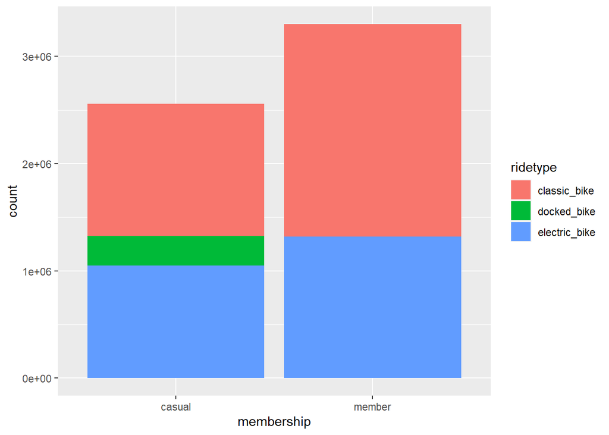

```r
ggplot(data = test1) +
  geom_bar(mapping= aes(x = membership,fill = ridetype))
```

See the average time of each membership Average ride time of casual members is twice of formal members

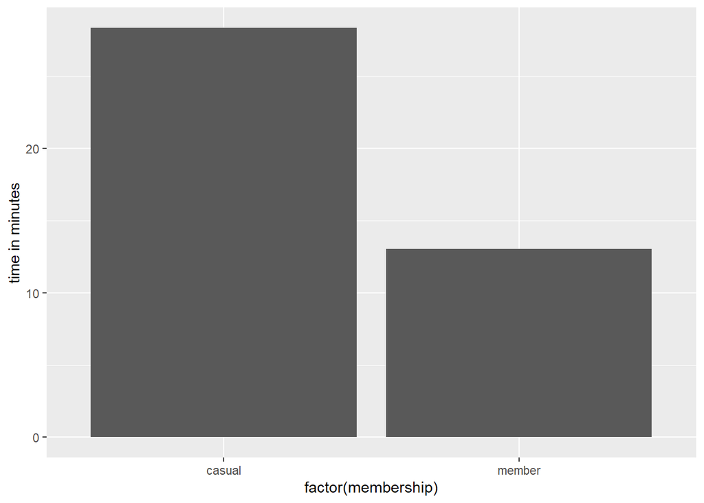

```r
ggplot(test1, aes(x = factor(membership), y = time)) +
  geom_bar(stat = "summary", fun = "mean") +
   scale_y_continuous("time in minutes")
```

Let’s see the average time of ride by different days of the week and membership type

```r
newtest <-test1 %>% group_by(membership,dayofweek) %>% drop_na() %>%
  summarize(mean1 =mean(time))
```

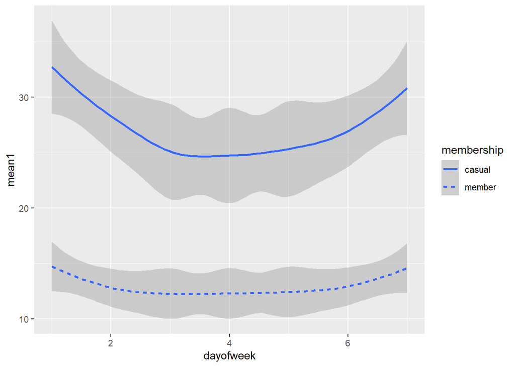

```r
ggplot(data = newtest) +
  geom_smooth(mapping = aes(x = dayofweek,
                           y = mean1,linetype = membership))
```

As we can see, monday and Sunday for both members and non-members are the days with the longest ride time.

Finally, let’s investigate the relationship between riding habits on different days by membership

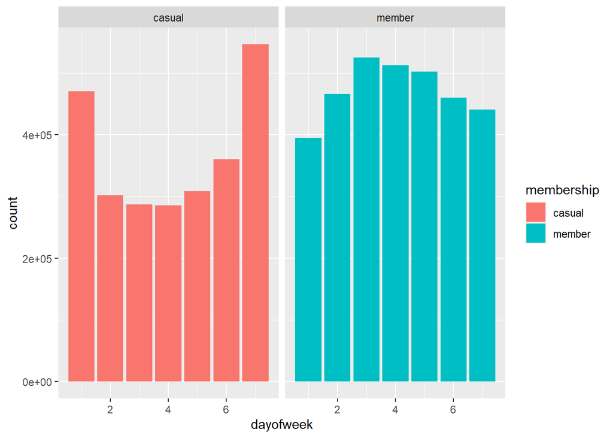

```r
ggplot(data = test1) +
  geom_bar(mapping= aes(x = dayofweek,fill  = membership)) + facet_wrap(~membership)
```

As we can see from the graph as well as the sql query, casual members outweigh formal members in Monday and Sunday. Possible promotion can apply to these days to turn casual into members